# Name space management for R

Abstract

“Name space management for R” published in R News.

Luke Tierney

## Introduction

In recent years R has become a major platform for the development of new data analysis software. As the complexity of software developed in R and the number of available packages that might be used in conjunction increase, the potential for conflicts among definitions increases as well. The name space mechanism added in R 1.7.0 provides a framework for addressing this issue.

Name spaces allow package authors to control which definitions provided by a package are visible to a package user and which ones are private and only available for internal use. By default, definitions are private; a definition is made public by *exporting* the name of the defined variable. This allows package authors to create their main functions as compositions of smaller utility functions that can be independently developed and tested. Only the main functions are exported; the utility functions used in the implementation remain private. An incremental development strategy like this is often recommended for high level languages like R—a guideline often used is that a function that is too large to fit into a single editor window can probably be broken down into smaller units. This strategy has been hard to follow in developing R packages since it would have lead to packages containing many utility functions that complicate the user’s view of the main functionality of a package, and that may conflict with definitions in other packages.

Name spaces also give the package author explicit control over the definitions of global variables used in package code. For example, a package that defines a function `mydnorm` as most likely intends `exp`, `sqrt`, and `pi` to refer to the definitions provided by the **base** package. However, standard packages define their functions in the global environment shown in Figure 1.

```
mydnorm <- function(z)
  1/sqrt(2 * pi) * exp(- z^2 / 2)
```

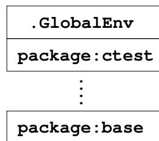

Figure 1: Dynamic global environment.

The global environment is dynamic in the sense that top level assignments and calls to `library` and `attach` can insert shadowing definitions ahead of the definitions in **base**. If the assignment `pi <- 3` has been made at top level or in an attached package, then the value returned by `mydnorm(0)` is not likely to be the value the author intended. Name spaces ensure that references to global variables in the **base** package cannot be shadowed by definitions in the dynamic global environment.

Some packages also build on functionality provided by other packages. For example, the package **modreg** uses the function `as.stepfun` from the **stepfun** package. The traditional approach for dealing with this is to use calls to `require` or `library` to add the additional packages to the search path. This has two disadvantages. First, it is again subject to shadowing. Second, the fact that the implementation of a package **A** uses package **B** does not mean that users who add **A** to their search path are interested in having **B** on their search path as well. Name spaces provide a mechanism for specifying package dependencies by *importing* exported variables from other packages. Formally importing variables from other packages again ensures that these cannot be shadowed by definitions in the dynamic global environment.

From a user’s point of view, packages with a name space are much like any other package. A call to `library` is used to load the package and place its exported variables in the search path. If the package imports definitions from other packages, then these packages will be loaded but they will not be placed on the search path as a result of this load.

## Adding a name space to a package

A package is given a name space by placing a ‘NAMESPACE’ file at the top level of the package source directory. This file contains *name space directives* that define the name space. This declarative approach to specifying name space information allows tools that collect package information to extract the package interface and dependencies without processing the package source code. Using a separate file also has the benefit of making it easy to add a name space to and remove a name space from a package.

The main name space directives are `export` and `import` directives. The `export` directive specifies names of variables to export. For example, the directive exports four variables. Quoting is optional for standard names such as these, but non-standard names need to be quoted, as in

```
export(as.stepfun, ecdf, is.stepfun, stepfun)
```

```
export("[<-.tracker")
```

As a convenience, exports can also be specified with a pattern. The directive exports all variables ending with `.test`.

```
exportPattern("\\.test$")
```

Import directives are used to import definitions from other packages with name spaces. The directive imports all exported variables from the package **mva**. The directive imports only the `as.stepfun` function from the **stepfun** package.

```
import(mva)
```

```
importFrom(stepfun, as.stepfun)
```

Two additional directives are available. The `S3method` directive is used to register methods for S3 generic functions; this directive is discussed further in the following section. The final directive is `useDynLib`. This directive allows a package to declaratively specify that a DLL is needed and should be loaded when the package is loaded.

For a package with a name space the two operations of loading the package and attaching the package to the search path are logically distinct. A package loaded by a direct call to `library` will first be loaded, if it is not already loaded, and then be attached to the search path. A package loaded to satisfy an import dependency will be loaded, but will *not* be attached to the search path. As a result, the single initialization hook function `.First.lib` is no longer adequate and is not used by packages with name spaces. Instead, a package with a name space can provide two hook functions, `.onLoad` and `.onAttach`. These functions, if defined, should not be exported. Many packages will not need either hook function, since import directives take the place of require calls and `useDynLib` directives can replace direct calls to `library.dynam`.

Name spaces are *sealed*. This means that, once a package with a name space is loaded, it is not possible to add or remove variables or to change the values of variables defined in a name space. Sealing serves two purposes: it simplifies the implementation, and it ensures that the locations of variable bindings cannot be changed at run time. This will facilitate the development of a byte code compiler for R (Tierney, 2001).

Adding a name space to a package may complicate debugging package code. The function `fix`, for example, is no longer useful for modifying an internal package function, since it places the new definition in the global environment and that new definition remains shadowed within the package by the original definition. As a result, it is a good idea not to add a name space to a package until it is completely debugged, and to remove the name space if further debugging is needed; this can be done by temporarily renaming the ‘NAMESPACE’ file. Other alternatives are being explored, and R 1.7.0 contains some experimental functions, such as `fixInNamespaces`, that may help.

## Name spaces and method dispatch

R supports two styles of object-oriented programming: the S3 style based on `UseMethod` dispatch, and the S4 style provided by the **methods** package. S3 style dispatch is still used the most and some support is provided in the name space implementation released in R 1.7.0.

S3 dispatch is based on concatenating the generic function name and the name of a class to form the name of a method. The environment in which the generic function is called is then searched for a method definition. With name spaces this creates a problem: if a package is imported but not attached, then the method definitions it provides may not be visible at the call site. The solution provided by the name space system is a mechanism for registering S3 methods with the generic function. A directive of the form in the ‘NAMESPACE’ file of a package registers the function `print.dendrogram` defined in the package as the `print` method for class `dendrogram`. The variable `print.dendrogram` does not need to be exported. Keeping the method definition private ensures that users will not inadvertently call the method directly.

```
S3method(print, dendrogram)
```

S4 classes and generic functions are by design more formally structured than their S3 counterparts and should therefore be conceptually easier to integrate with name spaces than S3 generic functions and classes. For example, it should be fairly easy to allow for both exported and private S4 classes; the concatenation-based approach of S3 dispatch does not seem to be compatible with having private classes except by some sort of naming convention. However, the integration of name spaces with S4 dispatch could not be completed in time for the release of R 1.7.0. It is quite likely that the integration can be accomplished by adding only two new directives, `exportClass` and `importClassFrom`.

### A simple example

A simple artificial example may help to illustrate how the import and export directives work. Consider two packages named **foo** and **bar**. The R code for package **foo** in file ‘foo.R’ is

```
x <- 1
f <- function(y) c(x,y)
```

The ‘NAMESPACE’ file contains the single directive

```
export(f)
```

Thus the variable `x` is private to the package and the function `f` is public. The body of `f` references a global variable `x` and a global function `c`. The global reference `x` corresponds to the definition in the package. Since the package does not provide a definition for `c` and does not import any definitions, the variable `c` refers to the definition provided by the **base** package.

The second package **bar** has code file ‘bar.R’ containing the definitions and ‘NAMESPACE’ file

```
c <- function(...) sum(...)
g <- function(y) f(c(y, 7))
```

```
import(foo)
export(g)
```

The function `c` is private to the package. The function `g` calls a global function `c`. Definitions provided in the package take precedence over imports and definitions in the **base** package; therefore the definition of `c` used by `g` is the one provided in **bar**.

Calling `library(bar)` loads **bar** and attaches its exports to the search path. Package **foo** is also loaded but not attached to the search path. A call to `g` produces

```
> g(6)
[1] 1 13
```

This is consistent with the definitions of `c` in the two settings: in **bar** the function `c` is defined to be equivalent to `sum`, but in **foo** the variable `c` refers to the standard function `c` in **base**.

### Some details

This section provides some details on the current implementation of name spaces. These details may change as name space support evolves.

Name spaces use R environments to provide static binding of global variables for function definitions. In a package with a name space, functions defined in the package are defined in a name space environment as shown in Figure 2. This environment consists of a set of three static frames followed by the usual dynamic global environment. The first static frame contains the local definitions of the package. The second frame contains imported definitions, and the third frame is the **base** package. Suppose the function `mydnorm` shown in the introduction is defined in a package with a name space that does not explicitly import any definitions. Then a call to `mydnorm` will cause R to evaluate the variable `pi` by searching for a binding in the name space environment. Unless the package itself defines a variable `pi`, the first binding found will be the one in the third frame, the definition provided in the **base** package. Definitions in the dynamic global environment cannot shadow the definition in **base**.

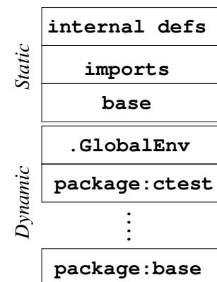

Figure 2: Name space environment.

When `library` is called to load a package with a name space, `library` first calls `loadNamespace` and then `attachNamespace`. `loadNamespace` first checks whether the name space is already loaded and registered with the internal registry of loaded name spaces. If so, the already loaded name space is returned. If not, then `loadNamespace` is called on all imported name spaces, and definitions of exported variables of these packages are copied to the imports frame, the second frame, of the new name space. Then the package code is loaded and run, and exports, S3 methods, and shared libraries are registered. Finally, the `.onLoad` hook is run, if the package defines one, and the name space is sealed. Figure 3 illustrates the dynamic global environment and the internal data base of loaded name spaces after two packages, **A** and **B**, have been loaded by explicit calls to `library` and package **C** has been loaded to satisfy import directives in package **B**.

The serialization mechanism used to save R workspaces handles name spaces by writing out a reference for a name space consisting of the package name and version. When the workspace is loaded, the reference is used to construct a call to `loadNamespace`. The current implementation ignores the version information; in the future this may be used to signal compatibility warnings or select among several available versions.

The registry of loaded name spaces can be examined using `loadedNamespaces`. In the current implementation loaded name spaces are not unloaded automatically. Detaching a package with a name space loaded by a call to `library` removes the frame containing the exported variables of the package from the global search path, but it does not unload the name space. Future implementations may automatically unload name spaces that are no longer needed to satisfy import dependencies. The function `unloadNamespace` can be used to force unloading of a name space; this can be useful if a new version of the package is to be loaded during development.

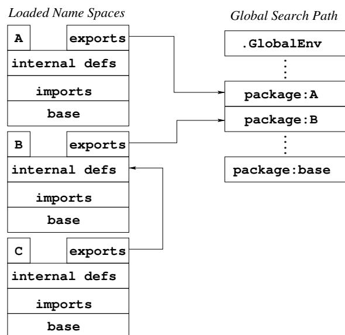

Figure 3: Internal implementation.

Variables exported by a package with a name space can also be referenced using a fully qualified variable reference consisting of the package name and the variable name separated by a double colon, such as `foo::f`. This can be useful in debugging at the top level. It can also occasionally be useful in source code, for example in cases where functionality is only to be used if the package providing it is available. However, dependencies resulting from use of fully qualified references are not visible from the name space directives and therefore may cause some confusion, so explicit importing is usually preferable. Computing the value of a fully qualified variable reference will cause the specified package to be loaded if it is not loaded already.

## Discussion

Name spaces provide a means of making R packages more modular. Many languages and systems originally developed without name space or module systems have had some form of name space management added in order to support the development of larger software projects. C++ and Tcl (Welch, 1999) are two examples. Other languages, such as Ada (Barnes, 1998) and Modula-3 (Harbison, 1992) were designed from the start to include powerful module systems. These languages use a range of approaches for specifying name space or module information. The declarative approach with separation of implementation code and name space information used in the system included in R 1.7.0 is closest in spirit to the approaches of Modula-3 and Ada. In contrast, Tcl and C++ interleave name space specification and source code.

The current R name space implementation, while already very functional and useful, is still experimental and incomplete. Support for S4 methods still needs to be included. More exhaustive error checking is needed, along with code analysis tools to aid in constructing name space specifications. To aid in package development and debugging it would also be useful to explore whether strict sealing can be relaxed somewhat without complicating the implementation. Early experiments suggest that this may be possible.

Some languages, including Ada, ML (Ullman, 1997) and the MzScheme Scheme implementation (PLT) provide a richer module structure in which parameterized partial modules can be assembled into complete modules. In the context of R this might correspond to having a parameterized generic data base access package that is completed by providing a specific data base interface. Whether this additional power is useful and the associated additional complexity is warranted in R is not yet clear.

## References

- John Barnes. *Programming In Ada 95*. Addison-Wesley, 2nd edition, 1998.
- Samuel P. Harbison. *Modula-3*. Prentice Hall, 1992.
- PLT. PLT MzScheme. World Wide Web, 2003. URL http://www.plt-scheme.org/software/mzscheme/.
- Luke Tierney. Compiling R: A preliminary report. In Kurt Hornik and Friedrich Leisch, editors, *Proceedings of the 2nd International Workshop on Distributed Statistical Computing, March 15-17, 2001, Technische Universität Wien, Vienna, Austria*, 2001. URL http://www.ci.tuwien.ac.at/Conferences/DSC-2001/Proceedings/. ISSN 1609-395X.
- Jeffrey Ullman. *Elements of ML Programming*. Prentice Hall, 1997.
- Brent Welch. *Practical Programming in Tcl and Tk*. Prentice Hall, 1999.